# 记一次心得分享

Shaodng ZHANG

2023-11-29

前一阵子我主动请缨参加了一次研究生毕业院校(以下匿称该校为“A校”)的分享会，时长10分钟，主要是向后辈总结介绍自己过去一年的研究生生活经验。会后我计划为此留下中文稿，所以写下这篇博文。分享会上使用的演示文稿可以在下方浏览，同时我也会以文字的形式在文中呈现，方便读者阅读跟进。

[figure not shown]

*提示：你可以使用键盘的左右按键来逐页显示幻灯片。*

## 目录

- 重点课程
- “水课”的情绪调节
- 目标导向&学以致用
- “笨鸟”先申
- 享受马德里

> 为了让听众可以对我演讲的内容先有一个大致了解，我一般会在幻灯片的第一页加上目录。在我看来只有分享内容本身足够吸引人或是充满循序渐进的惊喜的情况下（比如苹果公司的产品[发布会](https://www.youtube.com/live/ux6zXguiqxM?si=JZkCPqDQx3Kh1UoW&t=483)），幻灯片才可以省略目录。显然，经验分享就像一场学术报告：本身不一定足够吸引人，同时也很难产生惊喜。因此，我选择先列出目录，让听众了解梗概，顺便如果感觉无趣的话，可以尽早离席，以节省自己的时间。

## 重点课程

- 数据分析类课程 e.g. Probability and Statistics, Data Analytics, etc.
  - 量化分析=前沿的研究方法
  - 掌握一门新的技能有利于生存
- 科学研究方法类课程 e.g. Comparative Politics in Europe, etc.
  - 完善世界观, 增加学术素养
    - 可证伪性、因果推断、选择偏差、Demand Effect……
- IR理论类课程 e.g. International Relations Theory and Strategy, etc.
  - 多角度认识国际关系

> 既然是研究生生活，学习自然是第一要义。A校设置的课程很多，但我主要将上述三类归为重点课程[^1]。数据分析的重要性近年来在各学科领域都有所体现，拿国际关系研究来说，在跨越千禧年之初，顶级期刊上发表的论文中运用定量研究方法的比例就已经超过了50%[^2]，且呈上升趋势。因此，不重视数据分析类课程就等于逆时代潮流而动。

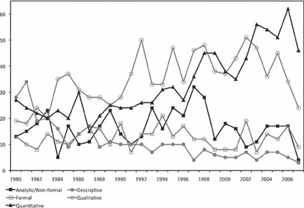

Methodology in International Relations by Year

> 其次，数据分析算是一门硬核技能，有助于提升我们的[核心竞争力](https://en.wikipedia.org/wiki/Core_competency),这对于将来找工作来说是很大的加分项[^3]。综上，数据分析类课程当仁不让的成为最重要的课程。

> 科学研究方法类课程在增加学术素养方面的功能自然不必多说，在我看来其更重要的作用在于完善和塑造我们的世界观和价值观。举例来说，了解[可证伪性](https://en.wikipedia.org/wiki/Falsifiability)的人几乎不会参与算命或者占卜；了解Demand Effect的人更倾向于“先做后说”；了解[因果推断](https://en.wikipedia.org/wiki/Causal_inference)的人在日常生活中更有可能避免[归因错误](https://en.wikipedia.org/wiki/Fundamental_attribution_error)。上述种种叠加在一起会潜移默化地强化一个人的理性思维，改变其看待客观世界的方式，进而影响价值观和世界观（甚至人生观）。

> 最后，毕竟是国际关系专业，老本行不能忘了，IR理论课可以帮助我们多角度思考国际关系，同时也有助于我们在特定范式内应用研究方法。

## “水课”的情绪调节

- 鉴别”水课”
  - 老师有无严肃认真的课业反馈
  - 老师有无使用最新的课件
- 面对”水课”
  - “没有’水课’你怎么活？？”
  - 适度控制自己的反感情绪对于获取知识有极大的帮助

> 在准备此次分享会伊始，我本不打算讲此节内容，毕竟我要出席的分享会上有A校的利益攸关方，但几经思索我还是决定添加这一部分内容，因为它很大程度可以影响学生的上学体验。我理解的水课是指的那些老师备课和课业反馈不认真，课堂内容空洞，课后作业冗杂繁多的课程。对于鉴别水课我个人有如上两个标准。举例来说，我之前遇到一名老师，上课多是侃大山[^4],每节课的课前作业都是给当堂要讲的内容写读书笔记，但是他从不认真反馈，最常见的评论是“*Good Job!*” ……这种课程在我看来是妥妥的水课。

> 面对这样的水课，要学会**控制自己的情绪**。一方面，水课不值得我们花费太多的时间来应对，应该对其合理分配精力；另一方面，要学会跟自己和解：**既然已经坐在教室里了，听而不闻即是浪费自己的时间，适度控制自己的反感情绪，反而可能有意外收货**。要知道，想做到“极致的无用”和“极致的有用”都是非常困难的事情[^5]——我们总能从“水课”中学到点什么。

## 目标导向&学以致用

- 以**就业导向**处理日常课业&小组合作。（王XX学姐）
- You have methodological skills that the vast majority of people working in the policy space **do not** have. **Look for opportunities to apply these skills**.（Prof. D.J. X）

> 这一节中没有我自己的原创内容，只是手动搬运了两条使我印象深刻且受益的建议。第一条建议是王某学姐在前年的分享会上提出的，对于有毕业实习要求的学生来说，从入学开始就以结果为导向是我十分认同的做法[^6]。

> 另外一句话是数据与决策课的任课老师（名为DJ）的结课语。这句话极大地引起了我的共鸣，因为我始终认为，学了不用就等于没学会，“用”才是学的最好办法，何况还是那么稀有的技能。

## “笨鸟”先申

- 完成既定计划的时间总比想象的要多
  - A校的学业压力临近毕业越来越大

[figure not shown]

  正负相关示意图

- UN申请是一场持久战
  - 海投、CV、CL的修改非常消耗时间和精力
  - 提早练手，有备无患

> 如前所述，A校要求学生毕业后到国际组织实习一段时间，所以我准备了此节内容。我们应该都有过明明计划缜密，但是实施起来还是超出预期时间的体验吧[^7]，对此我认为最好的解决办法就是笨鸟先飞[^8]。加之A院越临近毕业课程越紧，压力越大，这种模式与中国的高校有所不同，所以提前准备才是应对困难的良方。

## 享受马德里

- 劳逸结合
- 数不清的餐厅、酒吧和club
- 积极社交，扩大朋友圈
- 在马德里享受上述一切的成本比大部分欧洲国家要**低很多很多**…

> 最后，享受生活是我来到欧洲后才切身体会到的一点，所以也想分享给大家。我过去常常因为偷闲而产生一些罪恶感，在欧洲上学之后才发现享受生活、适度放纵是维持工作和学习效率的必要手段。我们的自控力是那么的有限，以至于在某些方面严于律己就会导致在其他方面懈怠。比如，复旦大学的“哲学王子”王德峰教授，在上课的时候常常吸烟（据此可想而知他日常生活中必定是烟不离手）。按理说如此有智慧的人不应该不知道“吸烟有害健康”，但是他还是选择继续吸烟，唯一的解释就是他在治学方面消耗了太多的自控力，所以在吸烟方面选择了“放纵自己”。因此，适度放纵自己是完全有益且有必要的，加之马德里的乐趣实在是太多，消费成本也相对较低，非常值得体验。

# 祝各位一切顺利，学业有成!!

[^1]: 即我认为的那些值得应该拿出大部分甚至全部精力关照的课程。
[^2]: Daniel Maliniak, Amy Oakes, Susan Peterson, Michael J. Tierney, International Relations in the US Academy, International Studies Quarterly, Volume 55, Issue 2, June 2011, Pages 437–464, https://doi.org/10.1111/j.1468-2478.2011.00653.x
[^3]: 我个人就是通过打造这一核心竞争力而入职了目前所从事的数据库管理岗位，在此之前我是一名妥妥的“文科生”。
[^4]: 侃大山是一个汉语方言词汇，拼音是kǎn dà shān。指长时间没完没了地说一些琐碎、不恰当或无效的话。
[^5]: 就像[正态分布](https://en.wikipedia.org/wiki/Normal_distribution)的两极一样。
[^6]: 这点类似于《高效能人士的七个习惯》作者史蒂夫科维的“[以始为终](https://www.franklincovey.com/the-7-habits/habit-2/)”理念。我当初就是考虑从事数据分析类工作，才将大部分精力都投入了相关课程，最终我也如愿找到了相关工作。
[^7]: 参考[Hofstadter’s Law](https://en.wikipedia.org/wiki/Hofstadter%27s_law#cite_note-geb20-2): It always takes longer than you expect, even when you take into account Hofstadter’s Law.
[^8]: 出自元·关汉卿《状元堂陈母教子》。这则成语比喻能力差的人惟恐落后而提前行动，多用于自谦。